# Live Session Unit_3 Assignment

Audrene Tiakor

January 27, 2019

# Question 1: GitHub Cloning (On to Local Machine)

### Steps:

1. Type the following url into browser:
2. https://github.com/caesar0301/awesome-public-datasets
3. Under the repository name, click clone or download.
4. In the clone, in the HTTPS section, copy the clone URL for the repository. Open Git Bash.
5. Change the current working directory to the location where you want the cloned directory to be (i.e.)
6. Type command ‘git clone’, then past the URL from step 2. It should look like this: $ git clone https://github.com/awesomedata/awesome-public-datasets.git Now you should have a cloned copy of the files in the place where you set your current working directory.

# Question 2: Data Summary

### a.

#### Read in the csv file ‘titanic.csv, assign it to ’df’

```r
setwd("C:\\Users\\Audrene\\Desktop\\SMU_MSDS_PROGRAM\\Term1_spring2019\\MSDS6306\\HW\\Live_session_3\\awesome-public-datasets\\Datasets")
df <- read.table(file = "titanic.csv", header = T, sep = ",")
```

### b.

#### Output total number of females and males with a frequency plot

```r
summary(df$Sex)
```

```
## female   male
##    314    577
```

```r
table(df$Sex)
```

```
##
## female   male
##    314    577
```

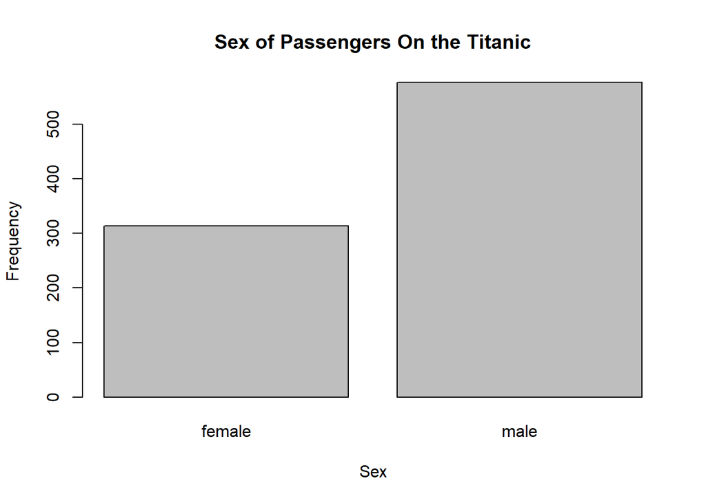

```r
barplot(table(df$Sex), main= "Sex of Passengers On the Titanic", xlab = "Sex", ylab = "Frequency")
```

### c.

#### Application of the ‘apply’ function for multiple columns

```r
sapply(df[,c("Age","Fare", "Survived")],mean, na.rm = TRUE)
```

```
##        Age       Fare   Survived
## 29.6991176 32.2042080  0.3838384
```

# Question 3: Function Building

*First need to read in the data set sleep_data_01.csv (found at http://talklab.psy.gla.ac.uk/L1_labs/lab_1/homework/index.html)

```r
setwd("C:\\Users\\Audrene\\Desktop\\SMU_MSDS_PROGRAM\\Term1_spring2019\\MSDS6306\\HW\\Live Session Unit 3 Assignment")
sleep <-read.csv(file = "sleep_data_01.csv", header = T, sep = ",")
```

*We need to create a function(x), that when out data sleep is read into it, will return MedianAge, SelfEsteem, SE_SD, and DurationRange. Here are the steps:

1. Create objects for the following: median Age, minimum and maximum duration of sleep, mean and standard deviation of RSES:
2. Create ‘data.frame’ Object Called ‘report’:
3. Change Column Names of ‘report’:
4. Round Numerical Outputs in ‘report’ to 2 digits

## FINAL RESULT

```r
sleep.function <- function(x) {

  med.age.sleep = median(x$Age,na.rm=TRUE)
  max.sleep.duration = max(x$Duration, na.rm=TRUE)
  min.sleep.duration = min(x$Duration, na.rm=TRUE)
  DurationRange = max.sleep.duration - min.sleep.duration
  mean.RSES.sleep = mean(x$RSES, na.rm=TRUE)
  sd.RSES.sleep = sd(x$RSES, na.rm = TRUE)
  report <- data.frame(med.age.sleep, mean.div.5= mean.RSES.sleep/5, sd.div.5 = sd.RSES.sleep/5, sleep.range = max.sleep.duration - min.sleep.duration)
  names(report)[1] <- paste("MedianAge")
  names(report)[2] <- paste("SelfEsteem")
  names(report)[3] <- paste("SE_SD")
  names(report)[4] <- paste("DurationRange")
  report = round(report, digits =2)
  return(report)

}
sleep.function(sleep)
```

```
##   MedianAge SelfEsteem SE_SD DurationRange
## 1        14       3.62  1.24             7
```

# Question 4: FiveThirtyEight Data

### a. Install the fivethirtyeight package:

```r
library(fivethirtyeight)
```

*Note: “college_recent_grads” is the 22nd data set in package fivethirtyeight

```r
data("college_recent_grads")
df<- college_recent_grads
```

### c. Write Out URL in a Comment

- Use the following code to find the URL:

```r
vignette("fivethirtyeight", package = "fivethirtyeight")
```

```
## starting httpd help server ... done
```

- https://fivethirtyeight.com/features/the-economic-guide-to-picking-a-college-major/

### d. Dimensions and Column Names for ‘df’:

```r
dim(df)
```

```
## [1] 173  21
```

```r
names(df)
```

```
##  [1] "rank"                        "major_code"
##  [3] "major"                       "major_category"
##  [5] "total"                       "sample_size"
##  [7] "men"                         "women"
##  [9] "sharewomen"                  "employed"
## [11] "employed_fulltime"           "employed_parttime"
## [13] "employed_fulltime_yearround" "unemployed"
## [15] "unemployment_rate"           "p25th"
## [17] "median"                      "p75th"
## [19] "college_jobs"                "non_college_jobs"
## [21] "low_wage_jobs"
```

# Question 5: Data Summary

### a. Number of Columns and Column Names for ‘df’:

```r
colnames(df)
```

```
##  [1] "rank"                        "major_code"
##  [3] "major"                       "major_category"
##  [5] "total"                       "sample_size"
##  [7] "men"                         "women"
##  [9] "sharewomen"                  "employed"
## [11] "employed_fulltime"           "employed_parttime"
## [13] "employed_fulltime_yearround" "unemployed"
## [15] "unemployment_rate"           "p25th"
## [17] "median"                      "p75th"
## [19] "college_jobs"                "non_college_jobs"
## [21] "low_wage_jobs"
```

```r
ncol(df)
```

```
## [1] 21
```

### b. Major Count

*Want to generate a count of each major category in the data frame ‘df’:

```r
library(plyr)
 major_count<- count(df, "major_category")
```

### c. Barplot of ‘major_count’

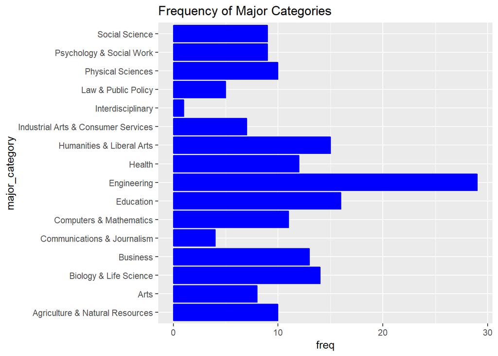

```r
library(ggplot2)
 ggplot(data=major_count, aes(x = major_category, y=freq))+geom_bar(stat="identity", color = "blue", fill="blue")+coord_flip()+ggtitle("Frequency of Major Categories")
```

save<-write.csv(df, file = “fivethiertyeight.csv”,row.names=FALSE, na=“”)

# GitHub Link

https://github.com/atiakor0/SMU_MSDS_6306.git